# Part II - Analysis for San Francisco Bay Ford GoBike Service 2019

## by Godswill Olubari

## Investigation Overview

> In this project, we want to demonstrate the importance and value of data visualization techniques in the data analysis process. First, I will be performing Data Cleaning and wrangling then exploration and visualization using frequently used libraries, such as NumPy, pandas, Matplotlib, and Seaborn. Then, in the second part we will produce a short presentation that illustrated interesting discovery from our dataset.

## Dataset Overview

> The data consists of information regarding over 183,000 rides made in a bike-sharing system covering the greater San Francisco Bay area. The data features include duration (secs) and others such as DateTime, customer type, gender, and some additional variables. Out of 16 specifications 9 are numerical, 2 are datetime, 4 are object type and 1 is boolean type.

## (Visualization 1)

The time range with the highest rides is within 8-9th hour which depict early morning and 17-18th hour depicting later in the day(evening). The higher ride frequencies for morning (8th and 9th hours) and evening (17th and 18th hours) can be automatically linked to rush hours where people leave for work and come back later in the evening.

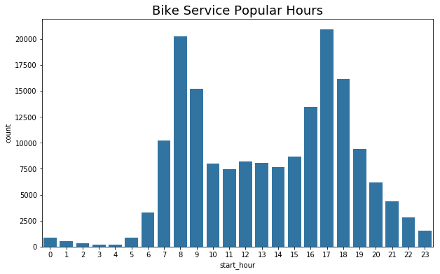

## (Visualization 2)

The real life scenerio should always be that those younger should take more rides. The plot above depicts exactly that showing that those within 17-45 years of age took more rides than those above 50 years. Looking at plot it can be deduce that most frequent users of bikes are aged between 17 and 45. Indicating younger members clocked Higher duration in seconds .

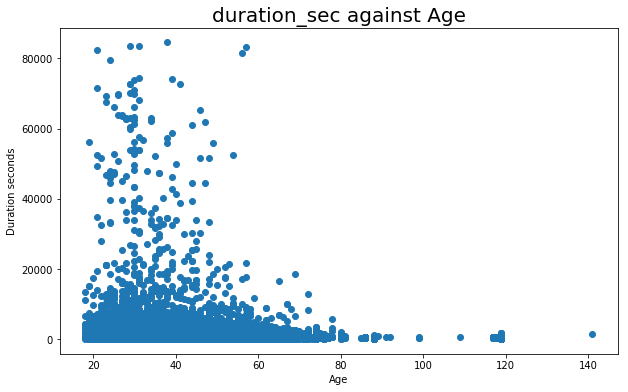

## (Visualization 3)

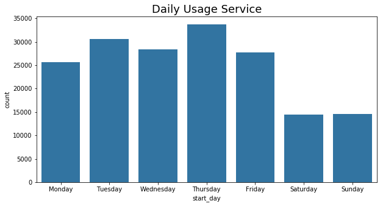

## (Visualization 4)

From the plot above we can see that higher percentage of customers are taking longer trips when compared to subscribers. Indicating Customer trips take a longer duration on average than subscriber user type.

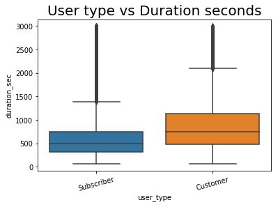

### Submission

If you are using classroom workspace, you can choose from the following two ways of submission:

1. **Submit from the workspace**. Make sure you have removed the example project from the /home/workspace directory. You must submit the following files:
   - Part_I_notebook.ipynb
   - Part_I_notebook.html or pdf
   - Part_II_notebook.ipynb
   - Part_I_slides.html
   - README.md
   - dataset (optional)
1. **Submit a zip file on the last page of this project lesson**. In this case, open the Jupyter terminal and run the command below to generate a ZIP file.

   ```
   zip -r my_project.zip .
   ```

   The command abobve will ZIP every file present in your /home/workspace directory. Next, you can download the zip to your local, and follow the instructions on the last page of this project lesson.